# Taller PCA — ANTES de las correcciones

Análisis con 14 variables sin transformación completa — Coffee Quality Institute

Juan Sebastián Guayazán · Esteban Valente · Diego Nocua

12 de noviembre de 2026

> **Propósito de este documento:** muestra el análisis en su estado **antes** de las correcciones pedidas por el profesor. Se usan las 14 variables originales con transformación Yeo-Johnson **solo** en `Category.Two.Defects`. Sirve como referencia para comparar y evidenciar los problemas (patrones en la matriz de dispersión, outliers de defectos físicos) que motivaron la transformación completa.

# 1. Objetivo

Se aplica PCA sobre 1.070 lotes de café arábica con las 14 variables cuantitativas disponibles, transformando únicamente `Category.Two.Defects` con Yeo-Johnson (λ ≈ −0.22).

# 2. Datos

```r
library(dplyr)

data <- read.csv("../data/arabica_data_cleaned.csv")

vars_cuantitativas <- c("Aroma", "Flavor", "Aftertaste", "Acidity", "Body",
                         "Balance", "Uniformity", "Clean.Cup", "Sweetness",
                         "Cupper.Points", "Moisture", "Category.One.Defects",
                         "Category.Two.Defects", "altitude_mean_meters")

data_f <- data %>%
  filter(is.na(altitude_mean_meters) | (altitude_mean_meters > 0 & altitude_mean_meters <= 3000)) %>%
  filter(!is.na(altitude_mean_meters))

datos <- data_f %>% select(all_of(vars_cuantitativas))
```

Tras el tratamiento: **1070 observaciones**, **14 variables**, sin datos faltantes.

# 3. Exploración inicial

```r
str(datos)
```

```
## 'data.frame':    1070 obs. of  14 variables:
##  $ Aroma               : num  8.67 8.75 8.42 8.17 8.25 8.25 8.67 8.08 8.17 8.25 ...
##  $ Flavor              : num  8.83 8.67 8.5 8.58 8.5 8.33 8.67 8.58 8.67 8.42 ...
##  $ Aftertaste          : num  8.67 8.5 8.42 8.42 8.25 8.5 8.58 8.5 8.25 8.17 ...
##  $ Acidity             : num  8.75 8.58 8.42 8.42 8.5 8.42 8.42 8.5 8.5 8.33 ...
##  $ Body                : num  8.5 8.42 8.33 8.5 8.42 8.33 8.33 7.67 7.75 8.08 ...
##  $ Balance             : num  8.42 8.42 8.42 8.25 8.33 8.5 8.42 8.42 8.17 8.17 ...
##  $ Uniformity          : num  10 10 10 10 10 10 9.33 10 10 10 ...
##  $ Clean.Cup           : num  10 10 10 10 10 10 10 10 10 10 ...
##  $ Sweetness           : num  10 10 10 10 10 9.33 9.33 10 10 10 ...
##  $ Cupper.Points       : num  8.75 8.58 9.25 8.67 8.58 9 8.67 8.5 8.58 8.5 ...
##  $ Moisture            : num  0.12 0.12 0 0.11 0.12 0.03 0.03 0.1 0.1 0 ...
##  $ Category.One.Defects: int  0 0 0 0 0 0 0 0 0 0 ...
##  $ Category.Two.Defects: int  0 1 0 2 2 0 0 4 1 0 ...
##  $ altitude_mean_meters: num  2075 2075 1700 2000 2075 ...
```

```r
dim(datos)
```

```
## [1] 1070   14
```

```r
summary(datos)
```

```
##      Aroma          Flavor        Aftertaste       Acidity           Body
##  Min.   :0.00   Min.   :0.000   Min.   :0.000   Min.   :0.000   Min.   :0.000
##  1st Qu.:7.42   1st Qu.:7.330   1st Qu.:7.250   1st Qu.:7.330   1st Qu.:7.330
##  Median :7.58   Median :7.540   Median :7.420   Median :7.500   Median :7.500
##  Mean   :7.57   Mean   :7.518   Mean   :7.391   Mean   :7.527   Mean   :7.505
##  3rd Qu.:7.75   3rd Qu.:7.750   3rd Qu.:7.580   3rd Qu.:7.750   3rd Qu.:7.670
##  Max.   :8.75   Max.   :8.830   Max.   :8.670   Max.   :8.750   Max.   :8.580
##     Balance        Uniformity       Clean.Cup        Sweetness
##  Min.   :0.000   Min.   : 0.000   Min.   : 0.000   Min.   : 0.000
##  1st Qu.:7.330   1st Qu.:10.000   1st Qu.:10.000   1st Qu.:10.000
##  Median :7.500   Median :10.000   Median :10.000   Median :10.000
##  Mean   :7.507   Mean   : 9.866   Mean   : 9.847   Mean   : 9.923
##  3rd Qu.:7.750   3rd Qu.:10.000   3rd Qu.:10.000   3rd Qu.:10.000
##  Max.   :8.750   Max.   :10.000   Max.   :10.000   Max.   :10.000
##  Cupper.Points       Moisture       Category.One.Defects Category.Two.Defects
##  Min.   : 0.000   Min.   :0.00000   Min.   : 0.0000      Min.   : 0.000
##  1st Qu.: 7.250   1st Qu.:0.10000   1st Qu.: 0.0000      1st Qu.: 0.000
##  Median : 7.500   Median :0.11000   Median : 0.0000      Median : 2.000
##  Mean   : 7.485   Mean   :0.09298   Mean   : 0.3748      Mean   : 3.555
##  3rd Qu.: 7.750   3rd Qu.:0.12000   3rd Qu.: 0.0000      3rd Qu.: 4.000
##  Max.   :10.000   Max.   :0.20000   Max.   :31.0000      Max.   :47.000
##  altitude_mean_meters
##  Min.   :   1
##  1st Qu.:1100
##  Median :1311
##  Mean   :1304
##  3rd Qu.:1600
##  Max.   :2560
```

## 3.1. Detección de valores atípicos univariados

```r
library(robustbase)
mc_vars <- sapply(datos, mc)
round(mc_vars, 3)
```

```
##                Aroma               Flavor           Aftertaste
##                0.030                0.000               -0.059
##              Acidity                 Body              Balance
##                0.000                0.000                0.000
##           Uniformity            Clean.Cup            Sweetness
##               -1.000               -1.000               -1.000
##        Cupper.Points             Moisture Category.One.Defects
##                0.000               -0.571                1.000
## Category.Two.Defects altitude_mean_meters
##                0.333                0.112
```

```r
asimetria_pearson <- sapply(datos, function(x) {
  3 * (mean(x) - median(x)) / sd(x)
})
round(asimetria_pearson, 3)
```

```
##                Aroma               Flavor           Aftertaste
##               -0.080               -0.162               -0.212
##              Acidity                 Body              Balance
##                0.208                0.038                0.052
##           Uniformity            Clean.Cup            Sweetness
##               -0.762               -0.575               -0.449
##        Cupper.Points             Moisture Category.One.Defects
##               -0.096               -1.140                0.599
## Category.Two.Defects altitude_mean_meters
##                0.883               -0.044
```

```r
comparar_outliers <- function(x) {
  clasico  <- sum(x < quantile(x, .25) - 1.5 * IQR(x) |
                  x > quantile(x, .75) + 1.5 * IQR(x))
  ab       <- adjboxStats(x)
  ajustado <- sum(x < ab$fence[1] | x > ab$fence[2])
  c(clasico = clasico, ajustado = ajustado)
}
tabla_outliers <- t(sapply(datos, comparar_outliers))
tabla_outliers
```

```
##                      clasico ajustado
## Aroma                     55       47
## Flavor                    31       31
## Aftertaste                63       66
## Acidity                   19       19
## Body                      23       23
## Balance                   35       35
## Uniformity               120      120
## Clean.Cup                 76       76
## Sweetness                 57       57
## Cupper.Points             25       25
## Moisture                 222      114
## Category.One.Defects     135      135
## Category.Two.Defects      77       20
## altitude_mean_meters      47       73
```

```r
par(mfrow = c(3, 5), mar = c(3, 2, 3, 1))
nombres_cortos <- c("Aroma","Flavor","Aftertaste","Acidity","Body",
                    "Balance","Uniformity","Clean.Cup","Sweetness",
                    "Cupper.Points","Moisture","Cat1.Defects","Cat2.Defects","Altitude")
for (i in seq_along(datos)) {
  n_out <- sum({ ab <- adjboxStats(datos[[i]]); datos[[i]] < ab$fence[1] | datos[[i]] > ab$fence[2] })
  adjbox(datos[[i]], main = paste0(nombres_cortos[i], "\n(", n_out, " atípicos)"),
         col = "lightblue", cex.main = 0.9, ylab = "")
}
```

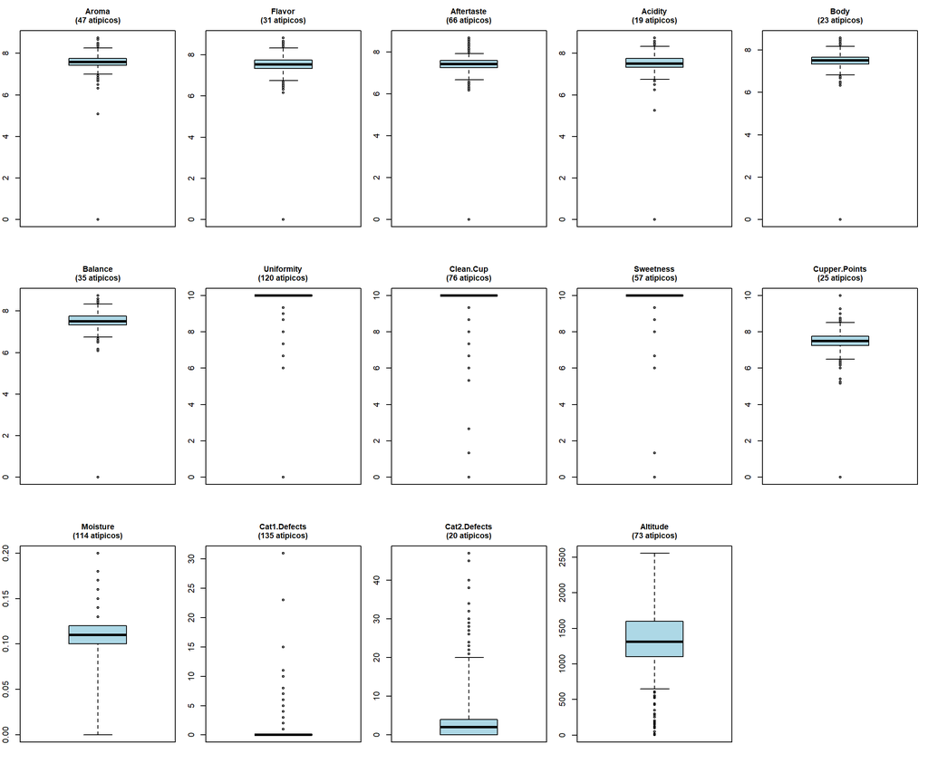

## 3.2. Transformación Yeo-Johnson — solo Category.Two.Defects

```r
yeojohnson_transform <- function(x, lambda) {
  if (lambda != 0) ((x + 1)^lambda - 1) / lambda else log(x + 1)
}
yeojohnson_loglik <- function(lambda, x) {
  y <- yeojohnson_transform(x, lambda)
  -length(x) / 2 * log(var(y)) + (lambda - 1) * sum(log(x + 1))
}
yeojohnson_fit <- function(x) {
  optimize(yeojohnson_loglik, interval = c(-5, 5), x = x, maximum = TRUE)$maximum
}

lambdas <- sapply(datos[c("Moisture", "Category.One.Defects", "Category.Two.Defects")],
                  yeojohnson_fit)
round(lambdas, 3)
```

```
##             Moisture Category.One.Defects Category.Two.Defects
##                5.000               -5.000               -0.217
```

```r
datos_transformados <- datos
datos_transformados$Category.Two.Defects <-
  yeojohnson_transform(datos$Category.Two.Defects, lambdas["Category.Two.Defects"])
```

# 4. Matriz de covarianza

```r
S <- cov(datos_transformados)
signif(S, 3)
```

```
##                        Aroma   Flavor Aftertaste  Acidity     Body  Balance
## Aroma                 0.1490  0.13000    0.12500  0.11200  0.10300  0.11900
## Flavor                0.1300  0.16400    0.14800  0.13200  0.11700  0.13800
## Aftertaste            0.1250  0.14800    0.16700  0.12700  0.11800  0.14100
## Acidity               0.1120  0.13200    0.12700  0.15000  0.10800  0.12200
## Body                  0.1030  0.11700    0.11800  0.10800  0.13100  0.12100
## Balance               0.1190  0.13800    0.14100  0.12200  0.12100  0.17400
## Uniformity            0.0870  0.09900    0.10100  0.09290  0.08400  0.10200
## Clean.Cup             0.1160  0.14300    0.14500  0.10800  0.09910  0.13800
## Sweetness             0.0806  0.09210    0.09190  0.08150  0.07770  0.08960
## Cupper.Points         0.1320  0.15800    0.15800  0.13500  0.12600  0.15400
## Moisture             -0.0018 -0.00237   -0.00304 -0.00192 -0.00301 -0.00403
## Category.One.Defects -0.0576 -0.03840   -0.05970 -0.04510 -0.01630 -0.04680
## Category.Two.Defects -0.0369 -0.04270   -0.05030 -0.03120 -0.02720 -0.04490
## altitude_mean_meters 27.2000 26.50000   26.30000 32.40000 18.30000 28.20000
##                      Uniformity Clean.Cup Sweetness Cupper.Points  Moisture
## Aroma                  0.087000    0.1160  0.080600       0.13200 -0.001800
## Flavor                 0.099000    0.1430  0.092100       0.15800 -0.002370
## Aftertaste             0.101000    0.1450  0.091900       0.15800 -0.003040
## Acidity                0.092900    0.1080  0.081500       0.13500 -0.001920
## Body                   0.084000    0.0991  0.077700       0.12600 -0.003010
## Balance                0.102000    0.1380  0.089600       0.15400 -0.004030
## Uniformity             0.280000    0.2090  0.156000       0.10300 -0.000418
## Clean.Cup              0.209000    0.6340  0.224000       0.15400 -0.001400
## Sweetness              0.156000    0.2240  0.263000       0.09220  0.000306
## Cupper.Points          0.103000    0.1540  0.092200       0.22300 -0.003880
## Moisture              -0.000418   -0.0014  0.000306      -0.00388  0.002010
## Category.One.Defects  -0.108000   -0.1900 -0.024300      -0.04080  0.005830
## Category.Two.Defects  -0.026100   -0.0792 -0.010300      -0.04930  0.005400
## altitude_mean_meters   9.140000   15.2000  2.060000      29.40000  0.043800
##                      Category.One.Defects Category.Two.Defects
## Aroma                            -0.05760              -0.0369
## Flavor                           -0.03840              -0.0427
## Aftertaste                       -0.05970              -0.0503
## Acidity                          -0.04510              -0.0312
## Body                             -0.01630              -0.0272
## Balance                          -0.04680              -0.0449
## Uniformity                       -0.10800              -0.0261
## Clean.Cup                        -0.19000              -0.0792
## Sweetness                        -0.02430              -0.0103
## Cupper.Points                    -0.04080              -0.0493
## Moisture                          0.00583               0.0054
## Category.One.Defects              3.52000               0.2410
## Category.Two.Defects              0.24100               0.4670
## altitude_mean_meters            -58.90000              23.0000
##                      altitude_mean_meters
## Aroma                            2.72e+01
## Flavor                           2.65e+01
## Aftertaste                       2.63e+01
## Acidity                          3.24e+01
## Body                             1.83e+01
## Balance                          2.82e+01
## Uniformity                       9.14e+00
## Clean.Cup                        1.52e+01
## Sweetness                        2.06e+00
## Cupper.Points                    2.94e+01
## Moisture                         4.38e-02
## Category.One.Defects            -5.89e+01
## Category.Two.Defects             2.30e+01
## altitude_mean_meters             1.75e+05
```

```r
varianza_total <- sum(diag(S))
cat("Varianza total (traza de S):", varianza_total, "\n")
```

```
## Varianza total (traza de S): 174662.4
```

```r
cat("Dominada por altitude_mean_meters:", round(S["altitude_mean_meters","altitude_mean_meters"],0), "\n")
```

```
## Dominada por altitude_mean_meters: 174656
```

La varianza total está dominada por `altitude_mean_meters` — artefacto de unidades. Por eso el PCA se hace sobre datos estandarizados (R, no S).

# 5. PCA — 14 variables

```r
pca <- prcomp(datos_transformados, center = TRUE, scale. = TRUE)
summary(pca)
```

```
## Importance of components:
##                           PC1     PC2     PC3     PC4     PC5     PC6     PC7
## Standard deviation     2.5820 1.16025 1.12347 1.02200 0.91487 0.85145 0.71407
## Proportion of Variance 0.4762 0.09616 0.09016 0.07461 0.05978 0.05178 0.03642
## Cumulative Proportion  0.4762 0.57237 0.66252 0.73713 0.79691 0.84870 0.88512
##                            PC8     PC9    PC10    PC11    PC12    PC13    PC14
## Standard deviation     0.63523 0.53137 0.51049 0.48797 0.42143 0.39321 0.30257
## Proportion of Variance 0.02882 0.02017 0.01861 0.01701 0.01269 0.01104 0.00654
## Cumulative Proportion  0.91394 0.93411 0.95272 0.96973 0.98242 0.99346 1.00000
```

```r
pca$sdev^2
```

```
##  [1] 6.66693138 1.34618590 1.26219065 1.04448261 0.83698986 0.72497347
##  [7] 0.50990159 0.40351249 0.28234955 0.26060290 0.23811063 0.17760715
## [13] 0.15461374 0.09154809
```

```r
cat("Componentes con lambda > 1 (Kaiser):", sum(pca$sdev^2 > 1), "\n")
```

```
## Componentes con lambda > 1 (Kaiser): 4
```

# 6. Screeplot

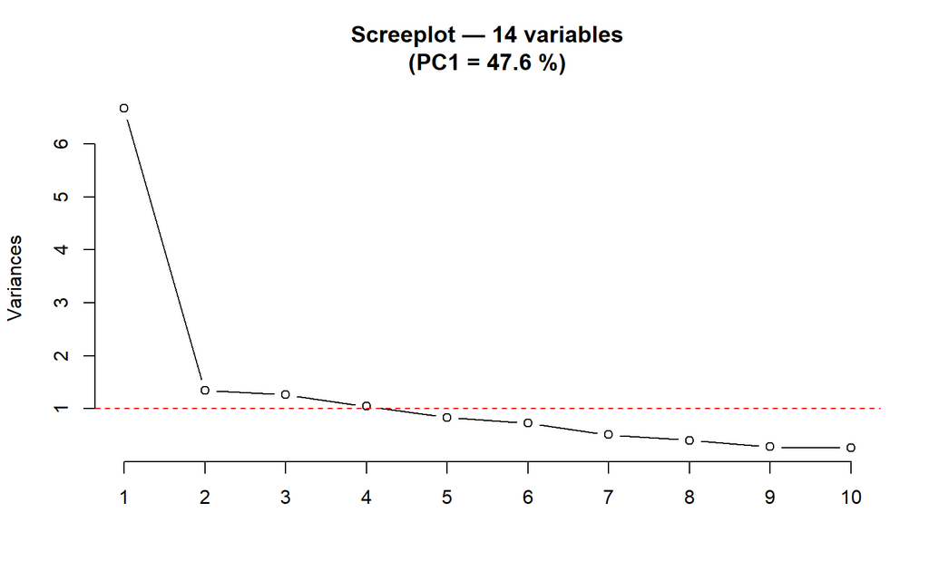

```r
screeplot(pca, type = "lines",
          main = paste0("Screeplot — 14 variables\n(PC1 = ",
                        round(pca$sdev[1]^2 / sum(pca$sdev^2) * 100, 1), " %)"))
abline(h = 1, lty = 2, col = "red")
```

# 7. Matriz de dispersión de scores

> **PROBLEMA VISIBLE:** el panel con `Category.One.Defects` y `Category.Two.Defects` muestra puntos extremos muy alejados de la nube principal (lotes con 23–31 defectos primarios). Estos outliers de defectos dominan ejes enteros (PC3 en las cargas) y son los “patrones” que el profesor identificó como problemáticos.

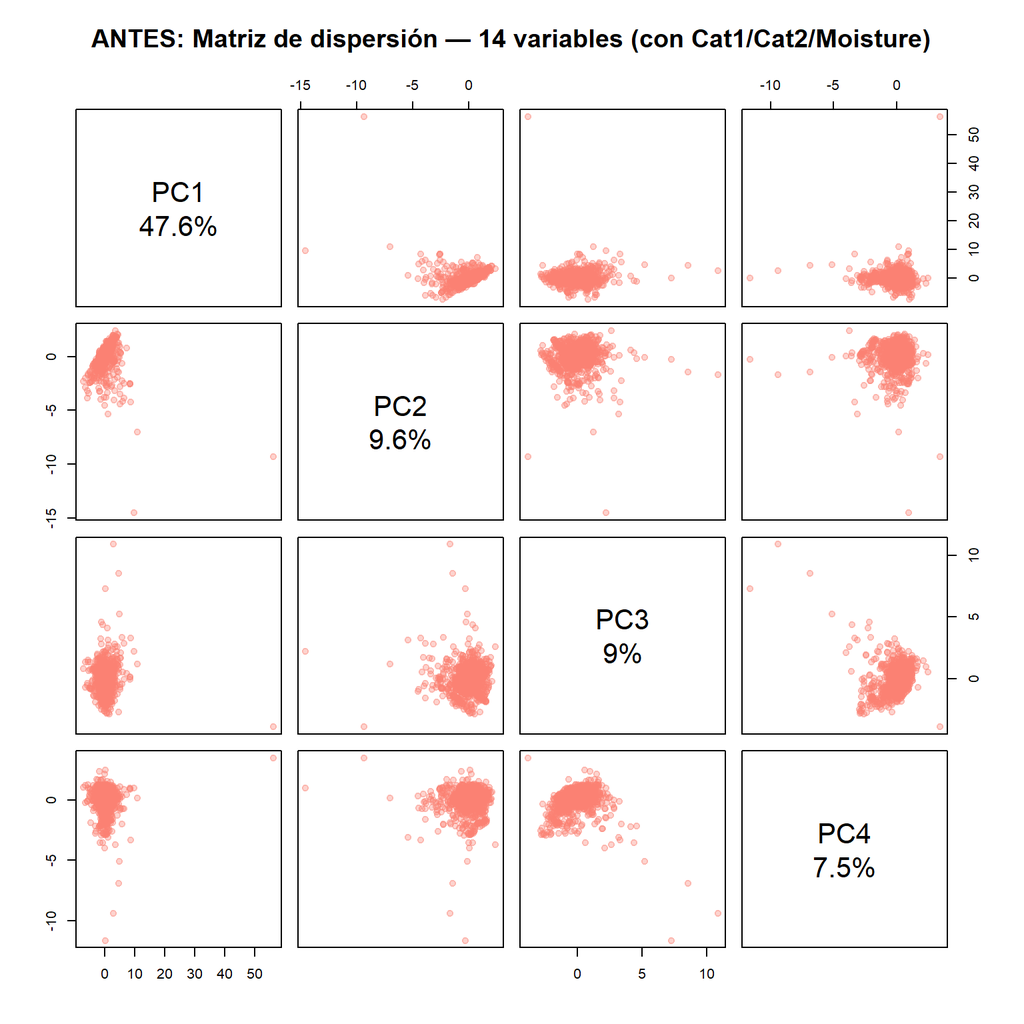

```r
k <- 4
pairs(pca$x[, 1:k],
      main = "ANTES: Matriz de dispersión — 14 variables (con Cat1/Cat2/Moisture)",
      pch = 19,
      col = adjustcolor("salmon", alpha.f = 0.35),
      labels = paste0("PC", 1:k, "\n",
                      round(pca$sdev[1:k]^2 / sum(pca$sdev^2) * 100, 1), "%"))
```

```r
idx_pc1 <- order(pca$x[, 1], decreasing = TRUE)[1:2]
idx_pc3 <- order(pca$x[, 3], decreasing = TRUE)[1:2]
datos[unique(c(idx_pc1, idx_pc3)), ]
```

|  | Aroma | Flavor | Aftertaste | Acidity | Body | Balance | Uniformity | Clean.Cup | Sweetness | Cupper.Points | Moisture | Category.One.Defects | Category.Two.Defects | altitude_mean_meters |
| --- | --- | --- | --- | --- | --- | --- | --- | --- | --- | --- | --- | --- | --- | --- |
| 1070 | 0.00 | 0.00 | 0.00 | 0.00 | 0.00 | 0.00 | 0.00 | 0.00 | 0 | 0.00 | 0.12 | 0 | 2 | 1400 |
| 1068 | 7.25 | 6.58 | 6.33 | 6.25 | 6.42 | 6.08 | 6.00 | 6.00 | 6 | 6.17 | 0.13 | 1 | 5 | 1100 |
| 1014 | 7.25 | 7.25 | 7.00 | 7.50 | 7.33 | 7.42 | 8.00 | 9.33 | 10 | 7.75 | 0.13 | 31 | 47 | 1300 |
| 1047 | 7.17 | 7.17 | 6.83 | 7.17 | 7.42 | 6.67 | 8.67 | 7.33 | 10 | 6.75 | 0.13 | 23 | 29 | 1280 |

# 8. Distancia de Mahalanobis — 14 variables

```r
dm2_14 <- mahalanobis(datos_transformados,
                      colMeans(datos_transformados),
                      cov(datos_transformados))
umbral_14 <- qchisq(0.975, df = ncol(datos_transformados))

cat("Umbral chi2_14 al 97.5%:", round(umbral_14, 1), "\n")
```

```
## Umbral chi2_14 al 97.5%: 26.1
```

```r
cat("Atípicos marcados:", sum(dm2_14 > umbral_14), "\n")
```

```
## Atípicos marcados: 85
```

```r
cat("\nTop 6 distancias:\n")
```

```
##
## Top 6 distancias:
```

```r
print(sort(dm2_14, decreasing = TRUE)[1:6])
```

```
## [1] 654.1481 410.5204 299.5585 287.6284 252.3664 187.0951
```

Con 14 variables se marcan **85** lotes como atípicos. Las distancias extremas (≈ 654, 410, 300) son muy altas porque Cat1/Cat2 con valores 31–47 generan distancias enormes en esas dimensiones.

# 9. Cargas — 14 variables

```r
cat("=== Cargas de las 4 primeras componentes (14 variables) ===\n")
```

```
## === Cargas de las 4 primeras componentes (14 variables) ===
```

```r
round(pca$rotation[, 1:4], 3)
```

```
##                         PC1    PC2    PC3    PC4
## Aroma                -0.333 -0.102  0.067  0.023
## Flavor               -0.362 -0.100  0.067 -0.028
## Aftertaste           -0.359 -0.103  0.019 -0.026
## Acidity              -0.338 -0.116  0.103  0.033
## Body                 -0.337 -0.132  0.078 -0.090
## Balance              -0.346 -0.121  0.017 -0.041
## Uniformity           -0.234  0.458 -0.061  0.033
## Clean.Cup            -0.216  0.468 -0.179  0.054
## Sweetness            -0.223  0.533  0.007 -0.056
## Cupper.Points        -0.337 -0.138  0.033 -0.047
## Moisture              0.071  0.368  0.405  0.219
## Category.One.Defects  0.039 -0.043  0.535 -0.594
## Category.Two.Defects  0.074  0.117  0.652  0.094
## altitude_mean_meters -0.071 -0.200  0.248  0.754
```

**PC3 es el “eje de defectos”** (Cat1 ≈ 0.54, Cat2 ≈ 0.65) y **PC4 es “altitud vs. defectos primarios”** (altitude ≈ 0.75, Cat1 ≈ −0.59). Estas dimensiones son artefactos de las variables problemáticas, no estructura real del café.

# 10. Biplot — 14 variables

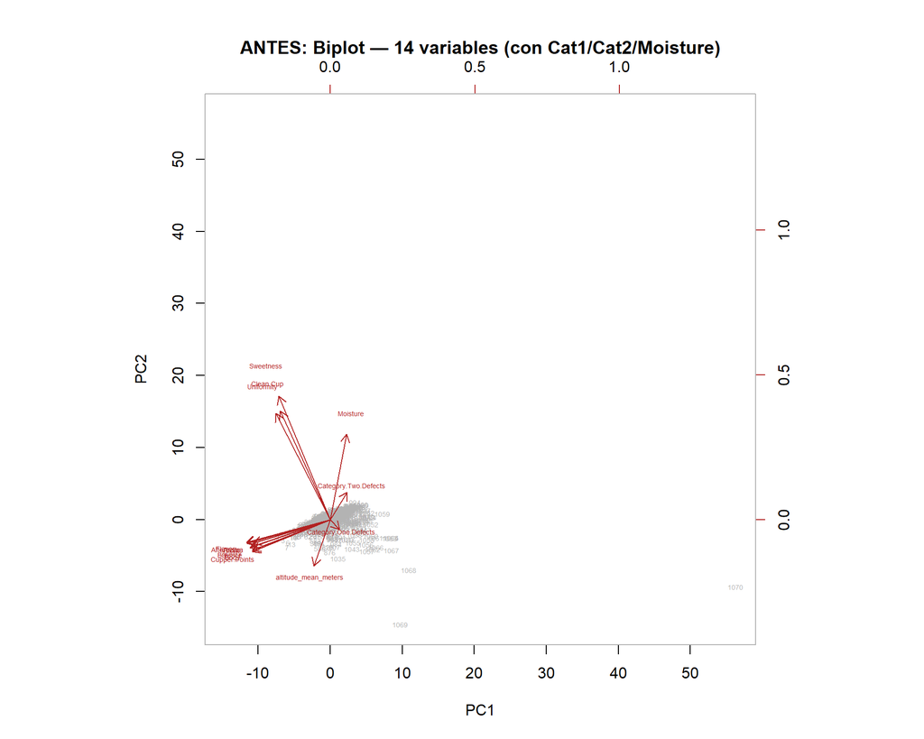

```r
biplot(pca, scale = 0, cex = 0.45,
       col = c("gray70", "firebrick"),
       main = "ANTES: Biplot — 14 variables (con Cat1/Cat2/Moisture)")
```